# Exercise 6

문지원

2021 4 27

# 단원문제 & 연습문제

### 단원문제 1

17. gapminder 데이터에 기록된 전 세계 인구의 구성 비율은 어떻게 변화하고 있을까?
1. 전체 관측 기간 중 1952년도의 인구 구성을 추출한 후 [그림 6-25]와 같이 시각화하라.

```r
library(dplyr)
```

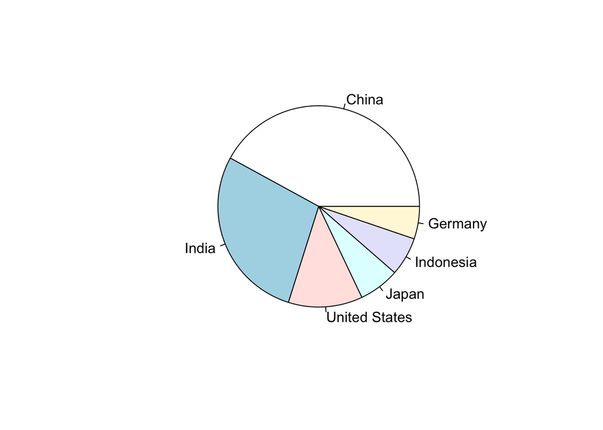

```r
library(ggplot2)
library(gapminder)
pop_1952 <-gapminder %>%
   filter(year== 1952) %>%
   arrange(desc(pop)) %>%
   head()
pie(pop_1952$pop, pop_1952$country)
```

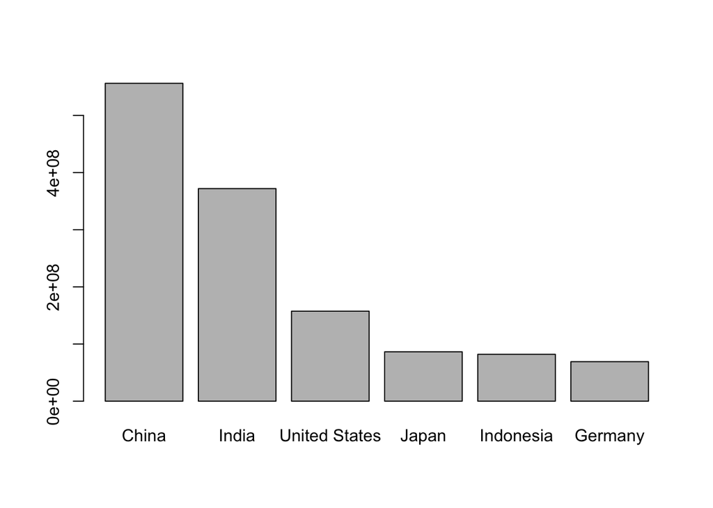

```r
barplot(pop_1952$pop, names.arg= pop_1952$country)
```

2. 1952년~2007년의 인구 구성을 for문을 이용해 반복적으로 시각화하라.

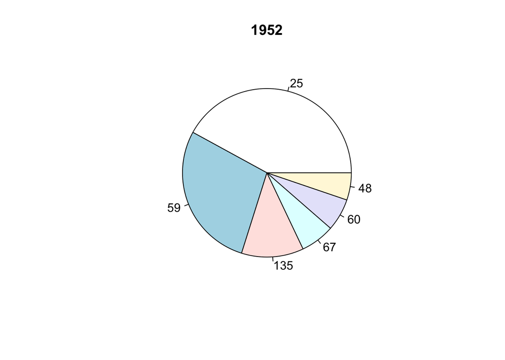

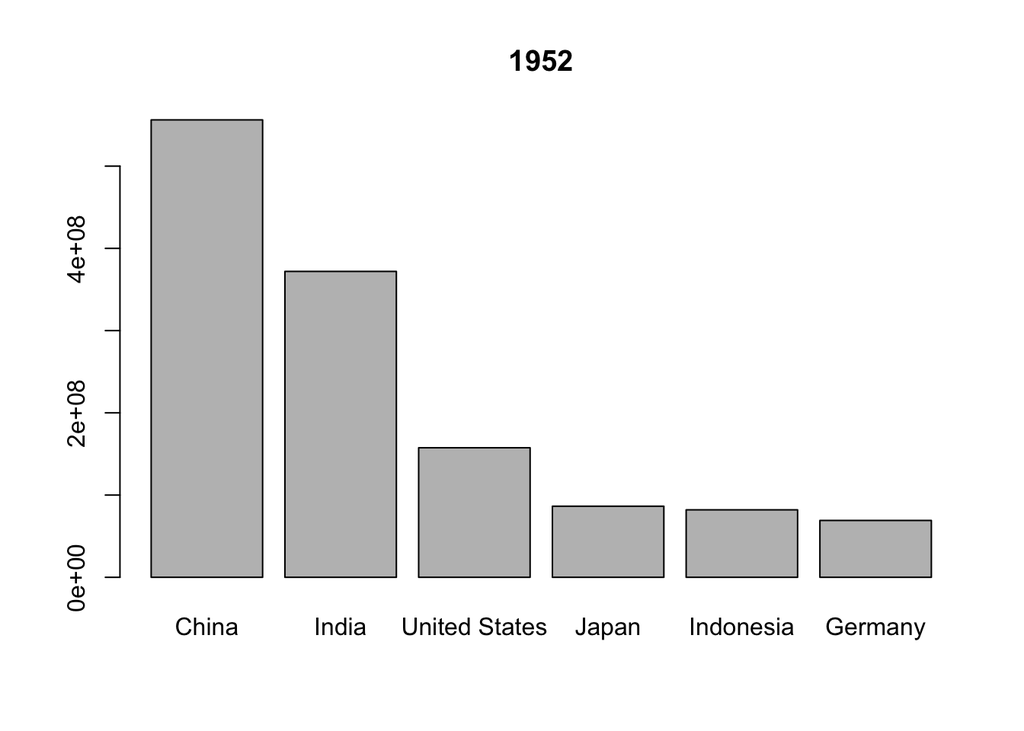

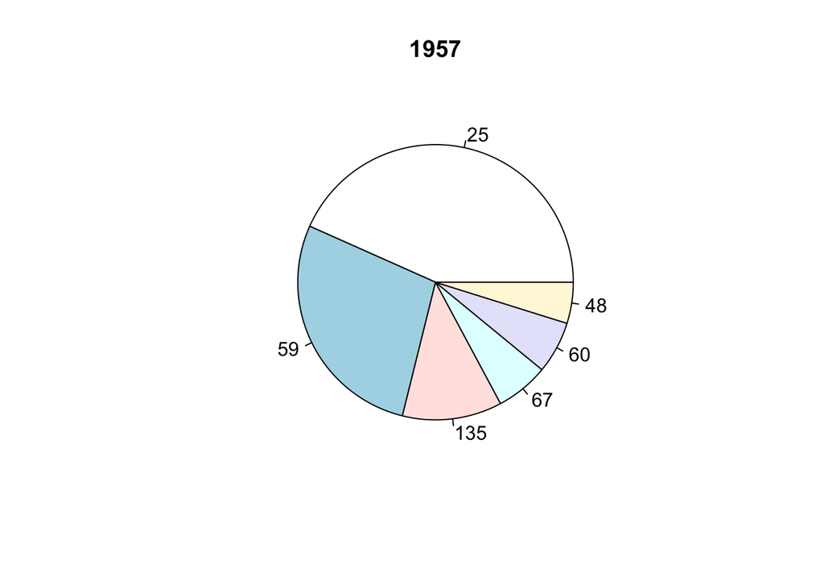

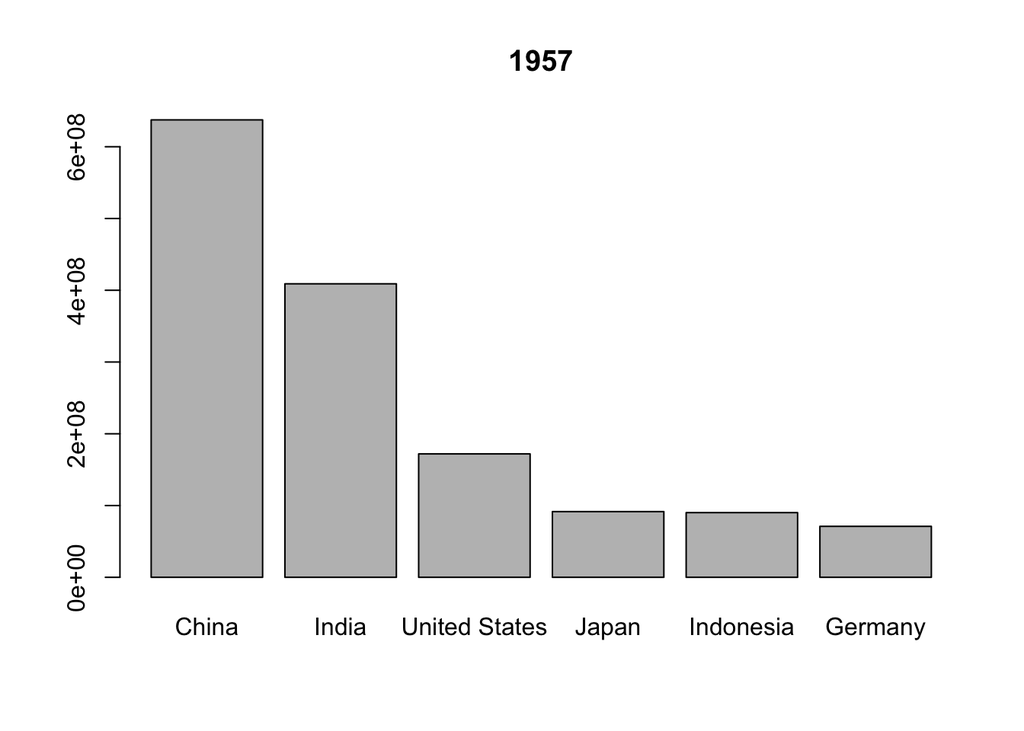

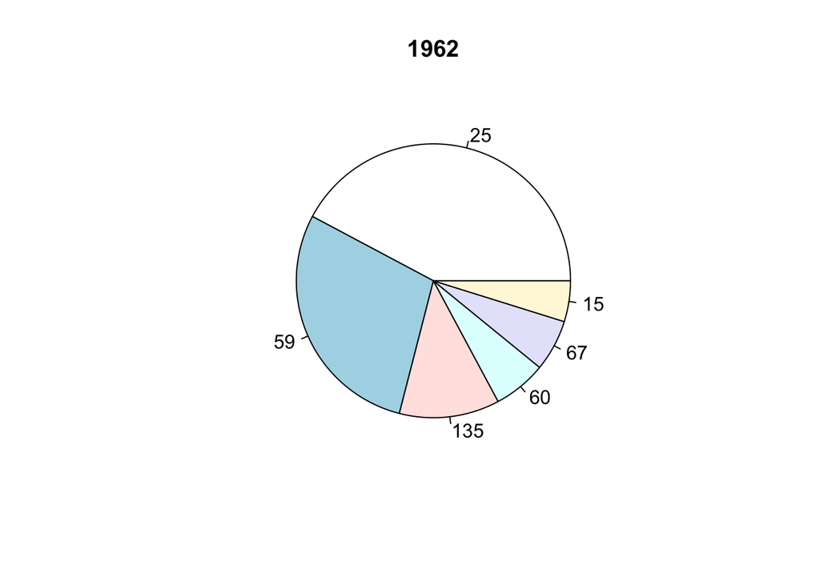

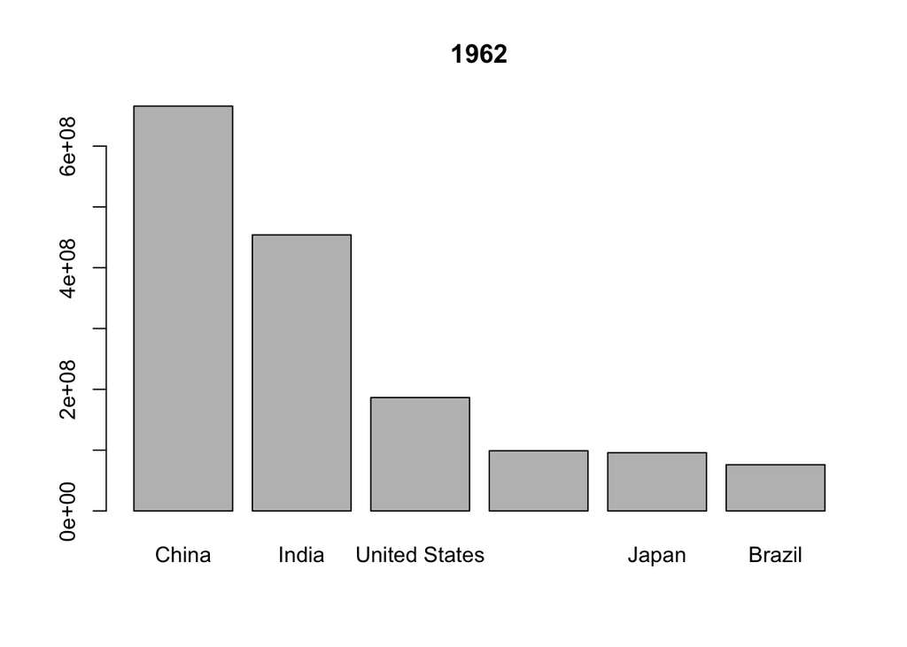

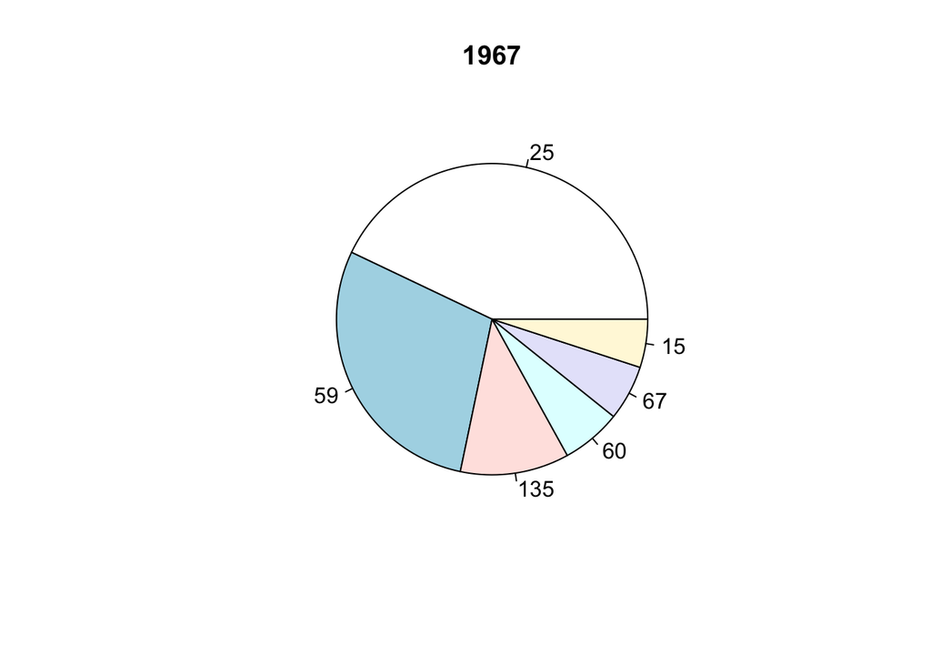

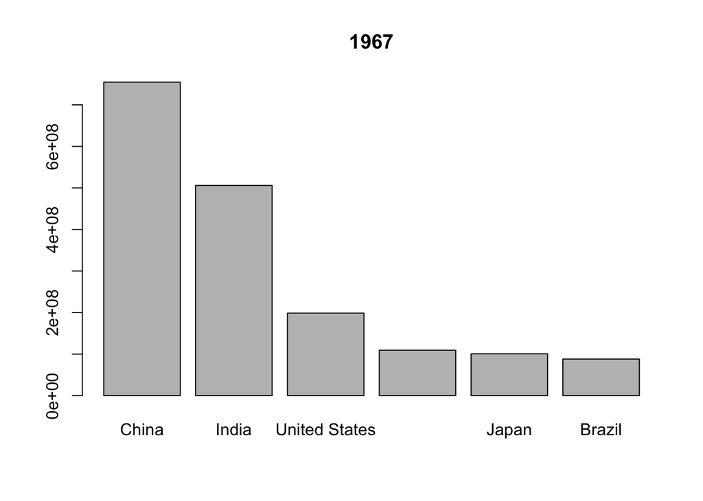

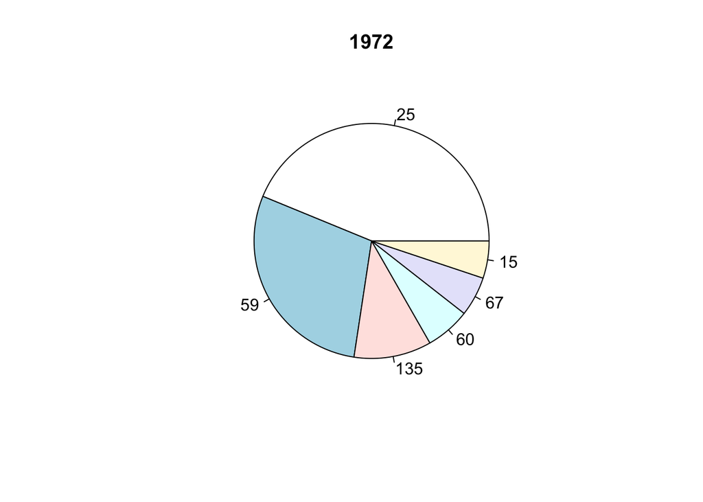

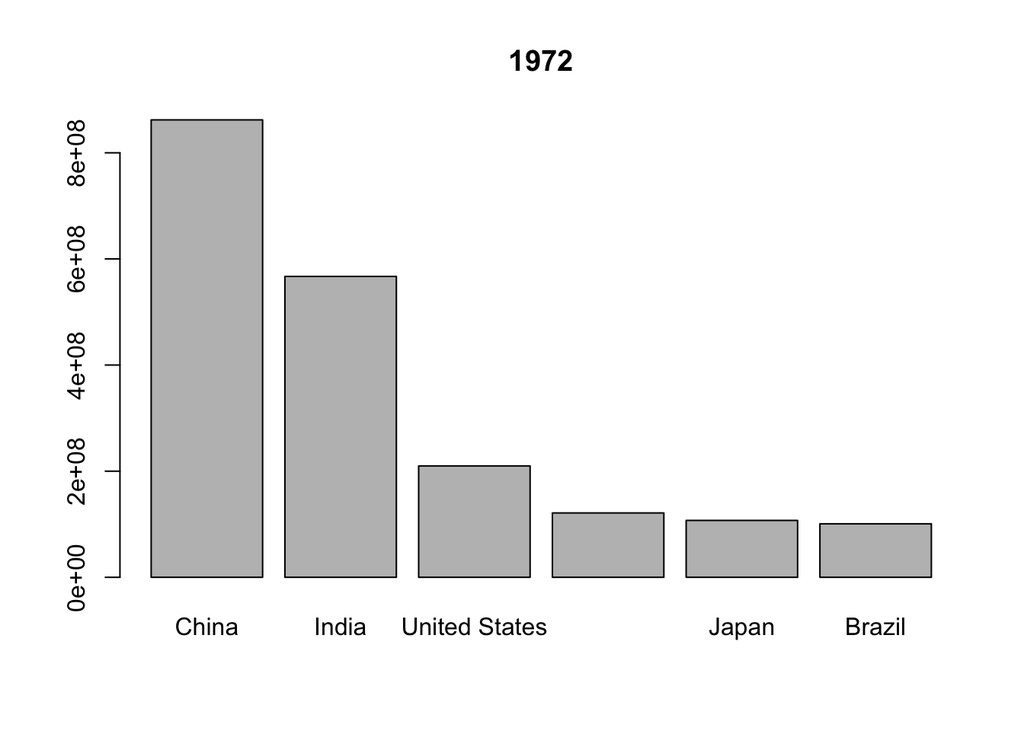

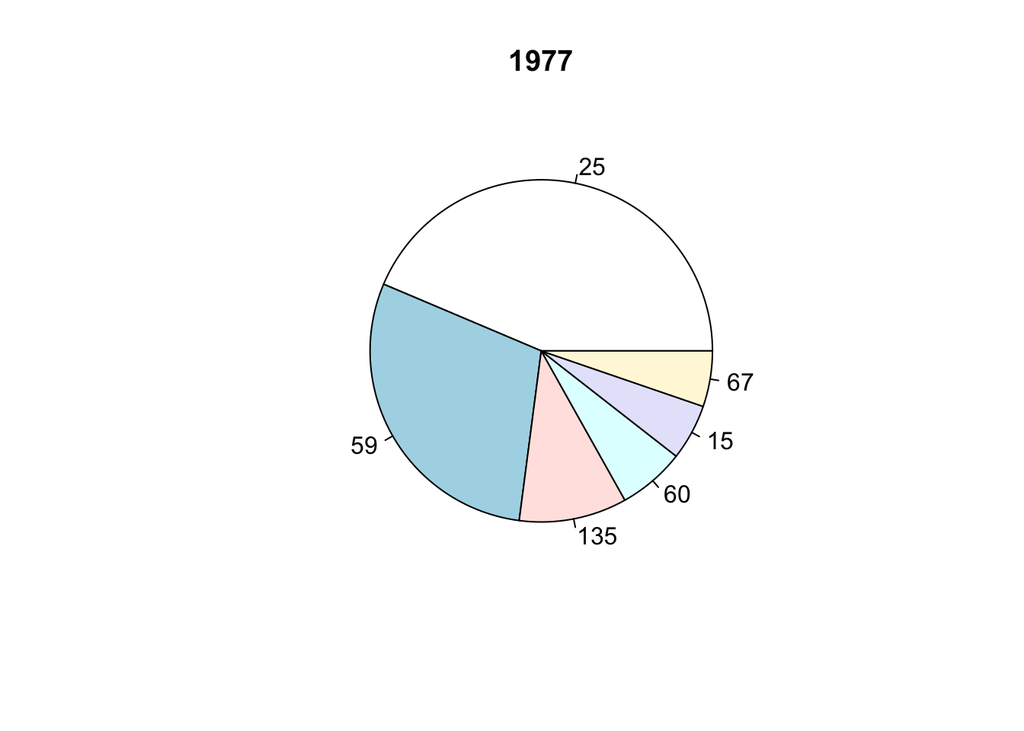

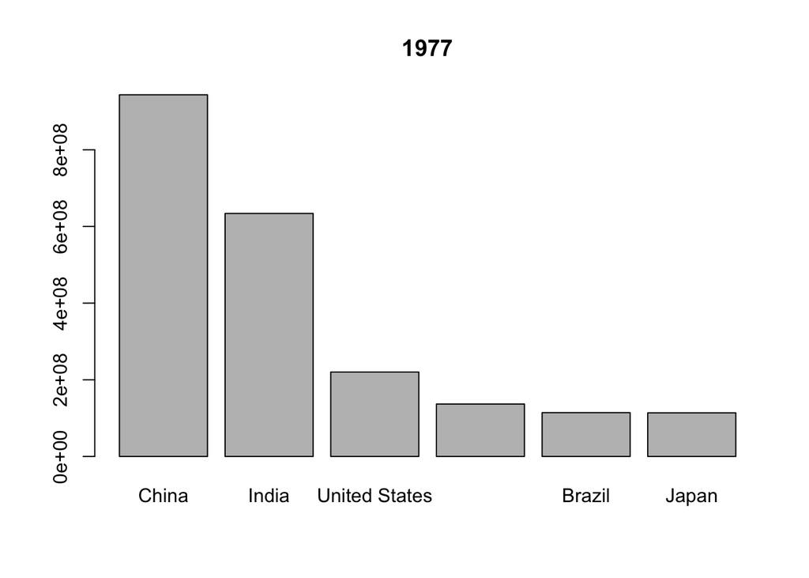

[12 more figures not shown]

```r
year_e <- seq(from = 1952,to = 2007, by = 5)
for(i in 1:12){
   pop_e<- gapminder %>%
      filter(year == year_e[i]) %>%
      arrange(desc(pop)) %>%
      head()
   pie(as.numeric(pop_e$pop), as.numeric(pop_e$country), main = year_e[i])
   barplot(pop_e$pop, names.arg=(pop_e$country), main = year_e[i])
}
```

3. 시각화 그래프를 통해 알게 된 사실을 몇 가지로 요약하라.

Ans) 1952년 부터 2007년까지 1, 2, 3위의 순위는 유지되었다(중국, 인도, 미국 순). 일본은 1962년 부터 순위가 하락세였고, 1977년 부터는 브라질에 밀렸다. 1997년 부터는 6위 밖으로 밀려나고 파키스탄이 6위를 차지했다.

### 연습문제 1

17. ggplot2를 이용하여 Iris 데이터 셋에 대해서 다음 문제를 푸세요.
1. 품종별로 Sepal/Petal의 Length, Width 산점도 그리기. (총 6개)

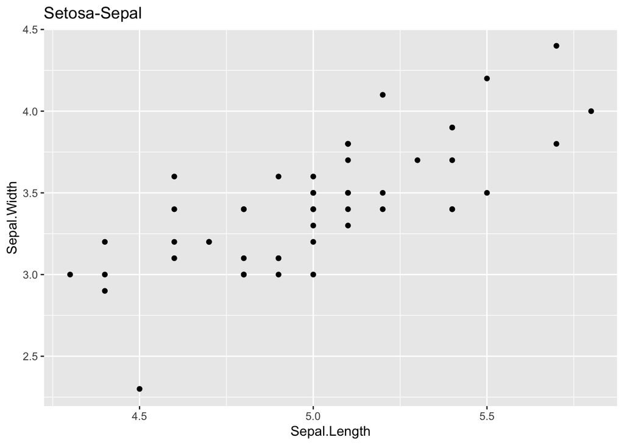

```r
iris_se <- iris %>%
   filter(Species== 'setosa')
ggplot(iris_se,aes(Sepal.Length, Sepal.Width)) +
   geom_point()+
      ggtitle('Setosa-Sepal')
```

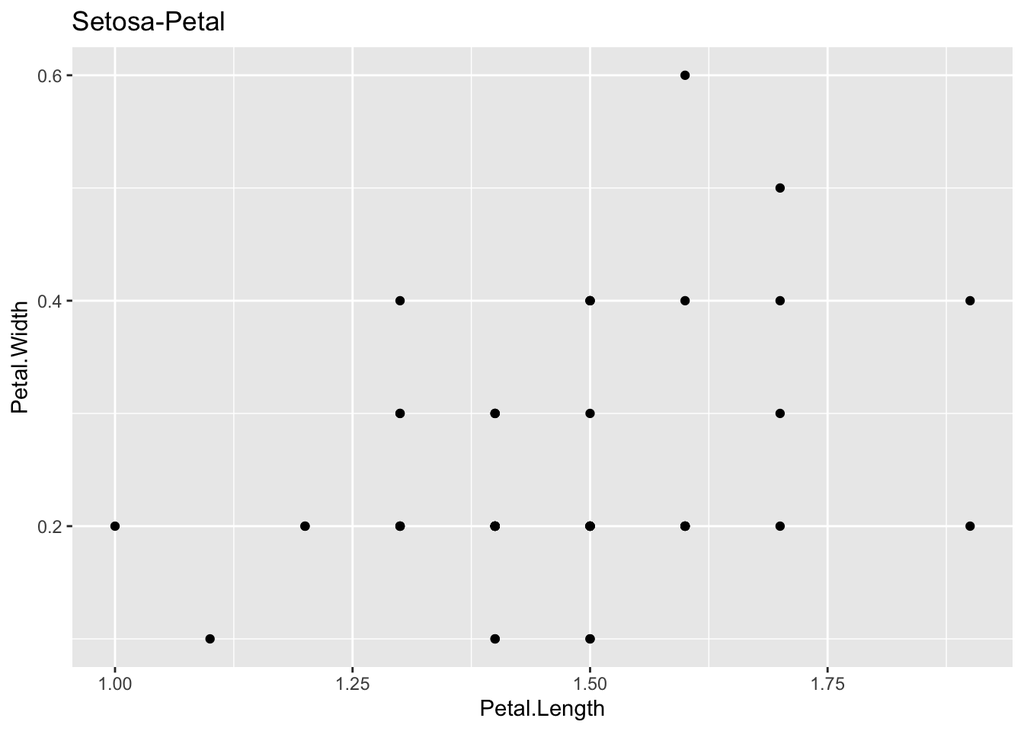

```r
iris_se <- iris %>%
   filter(Species== 'setosa')
ggplot(iris_se,aes(Petal.Length, Petal.Width)) +
   geom_point()+
      ggtitle('Setosa-Petal')
```

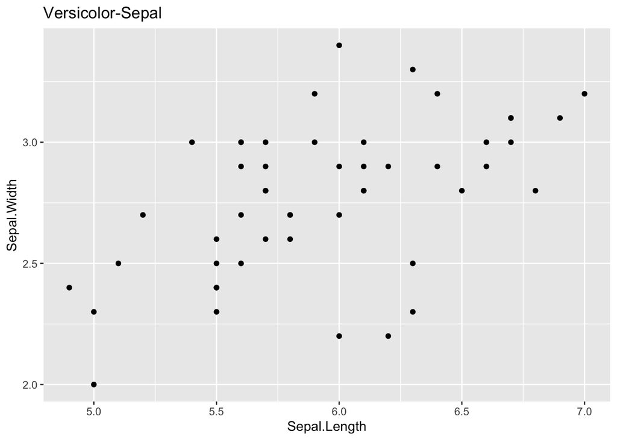

```r
iris_ve <- iris %>%
   filter(Species== 'versicolor')
ggplot(iris_ve,aes(Sepal.Length, Sepal.Width)) +
   geom_point()+
      ggtitle('Versicolor-Sepal')
```

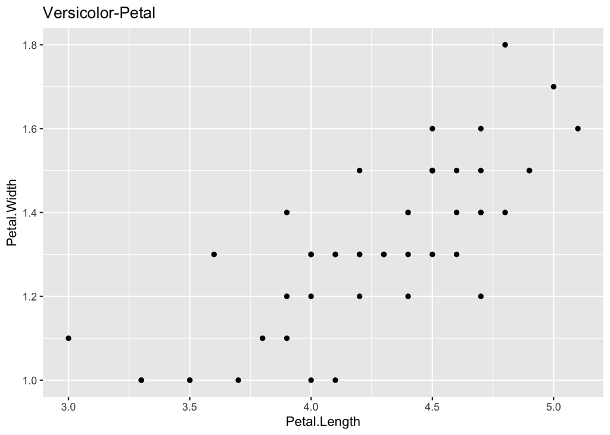

```r
iris_ve <- iris %>%
   filter(Species== 'versicolor')
   ggplot(iris_ve,aes(Petal.Length, Petal.Width)) +
   geom_point()+
      ggtitle('Versicolor-Petal')
```

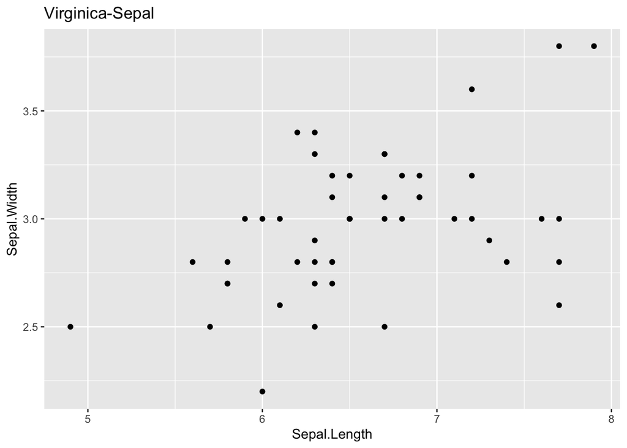

```r
iris_vi <- iris %>%
   filter(Species== 'virginica')
   ggplot(iris_vi,aes(Sepal.Length, Sepal.Width)) +
   geom_point()+
      ggtitle('Virginica-Sepal')
```

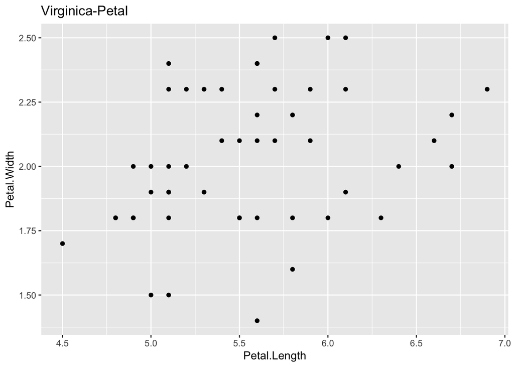

```r
iris_vi <- iris %>%
   filter(Species== 'virginica')
   ggplot(iris_vi,aes(Petal.Length, Petal.Width)) +
   geom_point()+
      ggtitle('Virginica-Petal')
```

2. 품종별 Sepal/Petal의 Length/Width 평균을 비교하되 항목을 옆으로 늘어놓은 것(beside=T)과 위로 쌓아올린 것 2개를 그리시오.(총 12개 항목의 데이터를 2개의 그래프에)

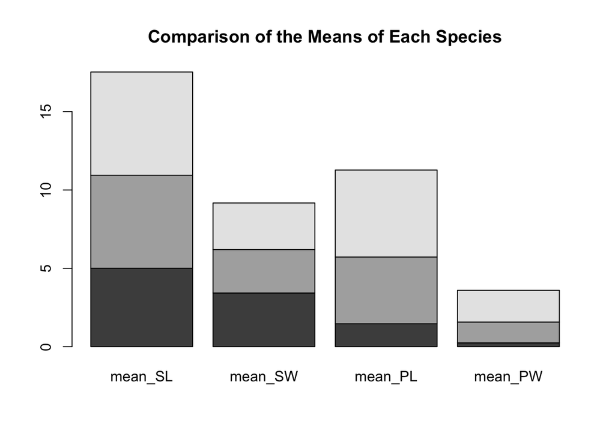

```r
iris_m <- iris %>%
   group_by(Species) %>%
   summarize(mean_SL=mean(Sepal.Length),mean_SW=mean(Sepal.Width),mean_PL=mean(Petal.Length),mean_PW=mean(Petal.Width))
barplot(as.matrix(iris_m[,c(2:5)]), main = "Comparison of the Means of Each Species")
```

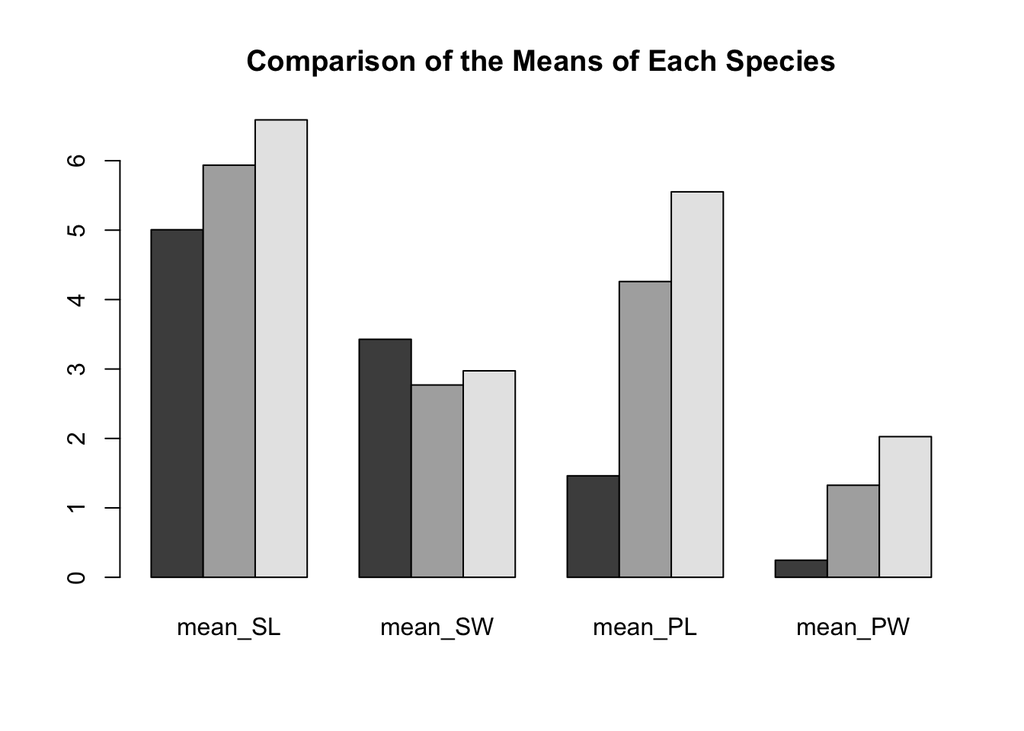

```r
iris_m <- iris %>%
   group_by(Species) %>%
   summarize(mean_SL=mean(Sepal.Length),mean_SW=mean(Sepal.Width),mean_PL=mean(Petal.Length),mean_PW=mean(Petal.Width))
barplot(as.matrix(iris_m[,c(2:5)]), main = "Comparison of the Means of Each Species", beside=T)
```

3. 박스 플롯 그리기

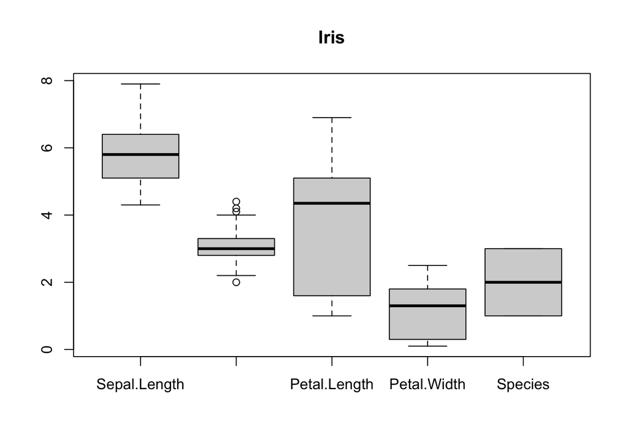

```r
boxplot(iris, main= "Iris")
```